# R Notebook

```r
df <- read_delim('cereal.csv', delim = ';')
View(df)
```

## Questions

1. What are the top 5 rated cereals?
2. Which manufacturer has the highest average rating?
3. Which cereals have high calories?
4. Which cereals have low calories?
5. How do cereals with low sugar and high fiber compare in terms of rating?
6. Are hot cereals better rated than cold cereals?
7. How many hot cereals are there compared to cold cereals?

````
```r
df <- df[-1,]

```
````

````
```r

df[-(1:3)] <- lapply(df[-(1:3)], function(x) as.numeric(as.character(x)))

```
````

````
```r
colnames(df)
```
````

[output not shown]

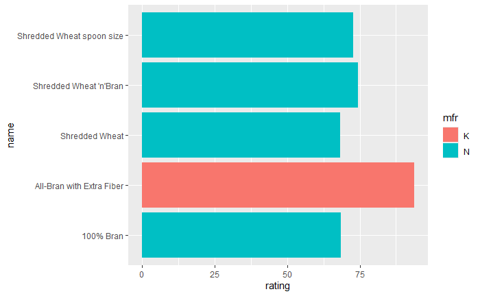

```r
ggplot(data = top_5, mapping = aes(x=rating , y = name , fill = mfr))+
  geom_bar(stat = "identity")
```

#### A = American Home Food Products; G = General Mills; K = Kelloggs; N = Nabisco; P = Post; Q = Quaker Oats; R = Ralston Purina.

```r
group_by(df, mfr)%>%
  summarise(
    avg_cal =mean(calories)
  )%>%
  arrange(avg_cal)
```

| mfr | avg_cal |
| --- | --- |
| N | 86.66667 |
| Q | 95.00000 |
| A | 100.00000 |
| K | 108.69565 |
| P | 108.88889 |
| G | 111.36364 |
| R | 115.00000 |

```r
mfr <- group_by(df, mfr)%>%
  summarise(avg_rating = mean(rating),
            avg_cal = mean(calories))%>%
  arrange(desc(avg_rating))

mfr
```

| mfr | avg_rating | avg_cal |
| --- | --- | --- |
| N | 67.96857 | 86.66667 |
| A | 54.85092 | 100.00000 |
| K | 44.03846 | 108.69565 |
| Q | 42.91599 | 95.00000 |
| P | 41.70574 | 108.88889 |
| R | 41.54300 | 115.00000 |
| G | 34.48585 | 111.36364 |

```r
#top 5 avg.rating manufacturar
#Nabisco
#American Home Food Products
#Kelloggs
#Quaker Oats
#Post
```

```r
mfr <- gather(mfr,event, avg,avg_rating:avg_cal)
mfr
```

| mfr | event | avg |
| --- | --- | --- |
| N | avg_rating | 67.96857 |
| A | avg_rating | 54.85092 |
| K | avg_rating | 44.03846 |
| Q | avg_rating | 42.91599 |
| P | avg_rating | 41.70574 |
| R | avg_rating | 41.54300 |
| G | avg_rating | 34.48585 |
| N | avg_cal | 86.66667 |
| A | avg_cal | 100.00000 |
| K | avg_cal | 108.69565 |

[output cut: 4 more lines]

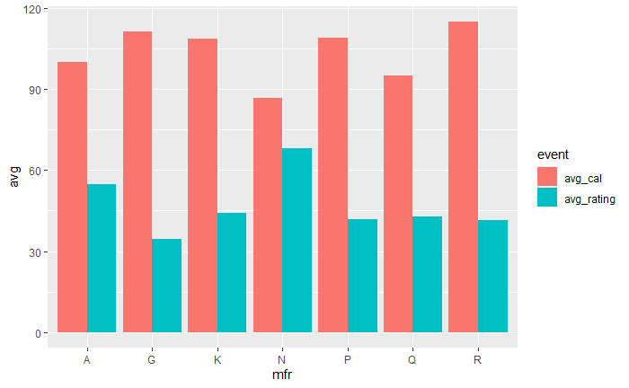

```r
ggplot(mfr, aes(x=mfr, y= avg ,fill= event))+
  geom_bar(stat = 'identity', position = 'dodge')
```

```r
arrange(df, calories)
```

| name | mfr | type | calories | protein | fat | sodium | fiber | carbo | sugars | potass | vitamins | shelf | weight | cups | rating |
| --- | --- | --- | --- | --- | --- | --- | --- | --- | --- | --- | --- | --- | --- | --- | --- |
| All-Bran with Extra Fiber | K | C | 50 | 4 | 0 | 140 | 14.0 | 8.0 | 0 | 330 | 25 | 3 | 1.00 | 0.50 | 93.70491 |
| Puffed Rice | Q | C | 50 | 1 | 0 | 0 | 0.0 | 13.0 | 0 | 15 | 0 | 3 | 0.50 | 1.00 | 60.75611 |
| Puffed Wheat | Q | C | 50 | 2 | 0 | 0 | 1.0 | 10.0 | 0 | 50 | 0 | 3 | 0.50 | 1.00 | 63.00565 |
| 100% Bran | N | C | 70 | 4 | 1 | 130 | 10.0 | 5.0 | 6 | 280 | 25 | 3 | 1.00 | 0.33 | 68.40297 |
| All-Bran | K | C | 70 | 4 | 1 | 260 | 9.0 | 7.0 | 5 | 320 | 25 | 3 | 1.00 | 0.33 | 59.42551 |
| Shredded Wheat | N | C | 80 | 2 | 0 | 0 | 3.0 | 16.0 | 0 | 95 | 0 | 1 | 0.83 | 1.00 | 68.23588 |
| Bran Chex | R | C | 90 | 2 | 1 | 200 | 4.0 | 15.0 | 6 | 125 | 25 | 1 | 1.00 | 0.67 | 49.12025 |
| Bran Flakes | P | C | 90 | 3 | 0 | 210 | 5.0 | 13.0 | 5 | 190 | 25 | 3 | 1.00 | 0.67 | 53.31381 |
| Nutri-grain Wheat | K | C | 90 | 3 | 0 | 170 | 3.0 | 18.0 | 2 | 90 | 25 | 3 | 1.00 | 1.00 | 59.64284 |
| Raisin Squares | K | C | 90 | 2 | 0 | 0 | 2.0 | 15.0 | 6 | 110 | 25 | 3 | 1.00 | 0.50 | 55.33314 |

[output cut: 67 more lines]

```r
View(arrange(df, desc(calories)))
```

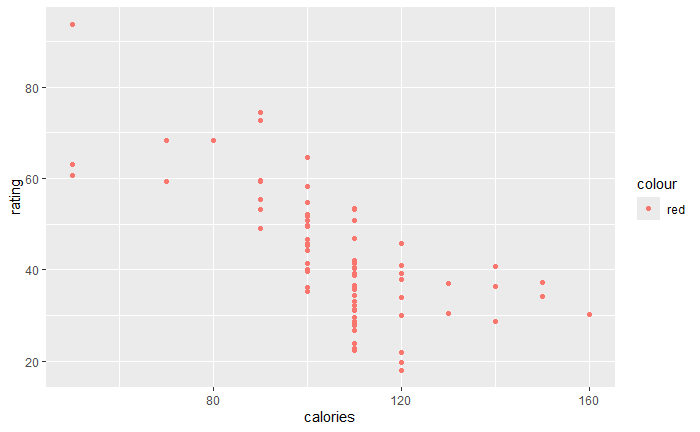

```r
ggplot(data =df, mapping = aes(x= calories, y = rating, color = 'red' ))+
  geom_point()
```

```r
NA
NA
```